# Clase 9. Aplicacion ARIMA(p, d, q) y ARMA(p, q)

Benjamin Oliva & Omar Alfaro-Rivera

02/10/2021

# Importamos Datos:

Los datos importados son:

- Pax_Nal: Pasajeros (Salidas) en vuelos nacionales
- Pax_Int: Pasajeros (Salidas) en vuelos internacionales
- Vue_Nal: Vuelos u operaciones (Salidas) en vuelos nacionales
- Vue_Int: Vuelos u operaciones (Salidas) en vuelos internacionales
- Pax_Metro: Pasajeros transportados (Millones) en el SCM
- D_Sep2017: Dummy que toma el valor de 1 en septiembre de 2017
- D_Oct2017: Dummy que toma el valor de 1 en octubre de 2017
- D_Feb2020: Dummy que toma el valor de 1 en febrero de 2020
- D_Mar2020: Dummy que toma el valor de 1 en marzo de 2020
- D_Abr2020: Dummy que toma el valor de 1 en abril de 2020
- D_May2020: Dummy que toma el valor de 1 en mayo de 2020
- D_Jun2020: Dummy que toma el valor de 1 en junio de 2020
- D_Jul2020: Dummy que toma el valor de 1 en julio de 2020
- D_Ene2021: Dummy que toma el valor de 1 en enero de 2021
- D_Mar2021: Dummy que toma el valor de 1 en marzo de 2021
- D_Ene: Dummy que toma el valor de 1 en todos los eneros
- D_Dic: Dummy que toma el valor de 1 en todos los diciembres

Fuente: INEGI, https://www.inegi.org.mx/app/indicadores/?tm=0&t=1090

```r
Datos <- read_excel("Base_Transporte_ARIMA.xlsx", sheet = "Datos", col_names = TRUE)

head(Datos)
```

```
## # A tibble: 6 × 22
##   Periodo             Pax_Nal Pax_Int Vue_Nal Vue_Int Pax_Metro D_Sep2…¹ D_Oct…²
##   <dttm>                <dbl>   <dbl>   <dbl>   <dbl>     <dbl>    <dbl>   <dbl>
## 1 2000-01-01 00:00:00 1378244  672734   30290    7812      112.        0       0
## 2 2000-02-01 00:00:00 1318075  649382   28291    7440      112.        0       0
## 3 2000-03-01 00:00:00 1476646  750587   31031    8036      121.        0       0
## 4 2000-04-01 00:00:00 1426550  718826   29896    7886      106.        0       0
## 5 2000-05-01 00:00:00 1529293  663015   31382    7498      118.        0       0
## 6 2000-06-01 00:00:00 1427266  633091   30514    7351      118.        0       0
## # … with 14 more variables: D_Feb2020 <dbl>, D_Mar2020 <dbl>, D_Abr2020 <dbl>,
## #   D_May2020 <dbl>, D_Jun2020 <dbl>, D_Jul2020 <dbl>, D_Ene2021 <dbl>,
## #   D_Mar2021 <dbl>, D_Ene <dbl>, D_Feb <dbl>, D_Jul <dbl>, D_Dic <dbl>,
## #   D_Ene2022 <dbl>, D_Feb2022 <dbl>, and abbreviated variable names
## #   ¹D_Sep2017, ²D_Oct2017
```

# Funciones que extrae y grafica las raices del polinomio caracteristico

```r
source("arroots.R")
source("maroots.R")
source("plot.armaroots.R")
```

# Conversion a series de tiempo:

```r
Pax_Nal <- ts(Datos$Pax_Nal,
              start = c(2000, 1),
              freq = 12)

LPax_Nal <- ts(log(Datos$Pax_Nal),
               start = c(2000, 1),
               freq = 12)

DLPax_Nal <- ts(log(Datos$Pax_Nal) - lag(log(Datos$Pax_Nal), k = 1),
                start = c(2000, 1),
                freq = 12)

D_Feb2020   <- ts(Datos$D_Feb2020,
                start = c(2000, 1),
                freq = 12)

D_Mar2020   <- ts(Datos$D_Mar2020,
                start = c(2000, 1),
                freq = 12)

D_Abr2020   <- ts(Datos$D_Abr2020,
                start = c(2000, 1),
                freq = 12)

D_May2020   <- ts(Datos$D_May2020,
                start = c(2000, 1),
                freq = 12)

D_Jun2020   <- ts(Datos$D_Jun2020,
                start = c(2000, 1),
                freq = 12)

D_Jul2020 <- ts(Datos$D_Jul2020,
                start = c(2000, 1),
                freq = 12)

D_Ene2021 <- ts(Datos$D_Ene2021,
                start = c(2000, 1),
                freq = 12)

D_Mar2021 <- ts(Datos$D_Mar2021,
                start = c(2000, 1),
                freq = 12)

D_Ene <- ts(Datos$D_Ene,
            start = c(2000, 1),
            freq = 12)

D_Feb <- ts(Datos$D_Feb,
            start = c(2000, 1),
            freq = 12)

D_Jul <- ts(Datos$D_Jul,
            start = c(2000, 1),
            freq = 12)

D_Dic <- ts(Datos$D_Dic,
            start = c(2000, 1),
            freq = 12)

D_Ene2022 <- ts(Datos$D_Ene2022,
                start = c(2000, 1),
                freq = 12)

D_Feb2022 <- ts(Datos$D_Feb2022,
                start = c(2000, 1),
                freq = 12)
```

# Graficas:

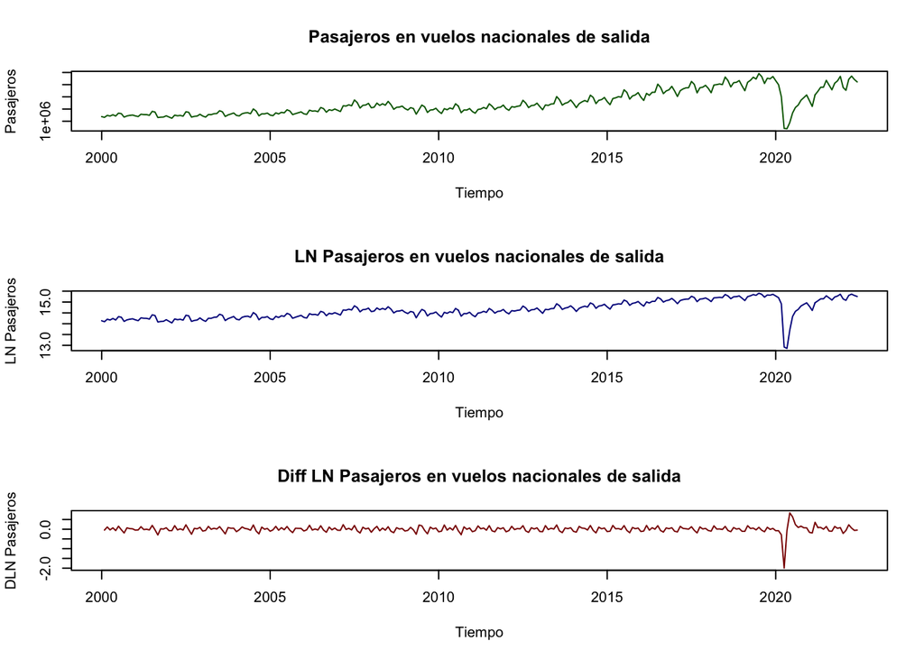

# Estimacion de ARIMA(1, 1, 1)

```r
ARMA_DLPax_Nal <- arima(DLPax_Nal, order = c(1, 0, 1),
                        xreg = cbind(D_Ene, D_Feb, D_Jul, D_Dic),
                        method = "ML")

ARMA_DLPax_Nal
```

```
##
## Call:
## arima(x = DLPax_Nal, order = c(1, 0, 1), xreg = cbind(D_Ene, D_Feb, D_Jul, D_Dic),
##     method = "ML")
##
## Coefficients:
##           ar1     ma1  intercept    D_Ene    D_Feb   D_Jul   D_Dic
##       -0.5663  0.8074     0.0020  -0.0992  -0.1192  0.1860  0.0637
## s.e.   0.1054  0.0689     0.0133   0.0369   0.0376  0.0337  0.0361
##
## sigma^2 estimated as 0.02491:  log likelihood = 114.84,  aic = -213.67
```

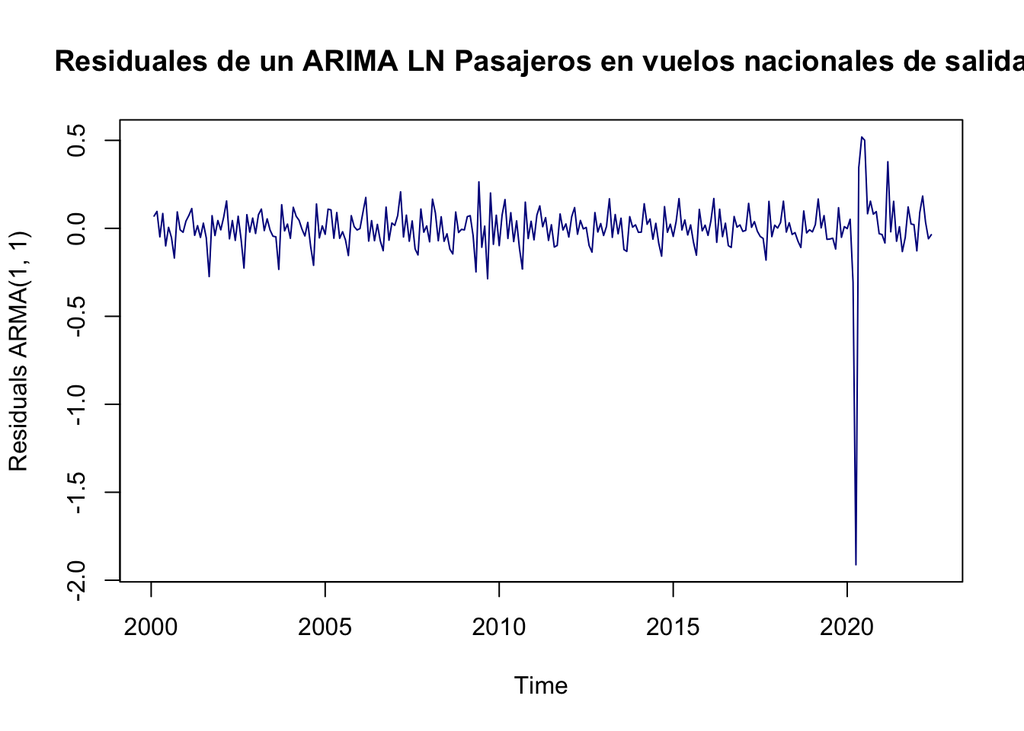

```r
#

plot(ARMA_DLPax_Nal$residuals,
     main = "Residuales de un ARIMA LN Pasajeros en vuelos nacionales de salida",
     col = "darkblue",
     ylab = "Residuals ARMA(1, 1)")
```

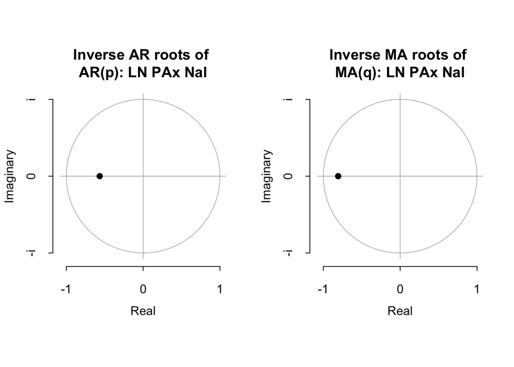

```r
#

par(mfrow=c(1,2))

plot.armaroots(arroots(ARMA_DLPax_Nal),
               main="Inverse AR roots of \nAR(p): LN PAx Nal")

plot.armaroots(maroots(ARMA_DLPax_Nal),
               main="Inverse MA roots of \nMA(q): LN PAx Nal")
```

```r
par(mfrow=c(1,1))
```

# Gráficas de las funciones de Autocorrelacion:

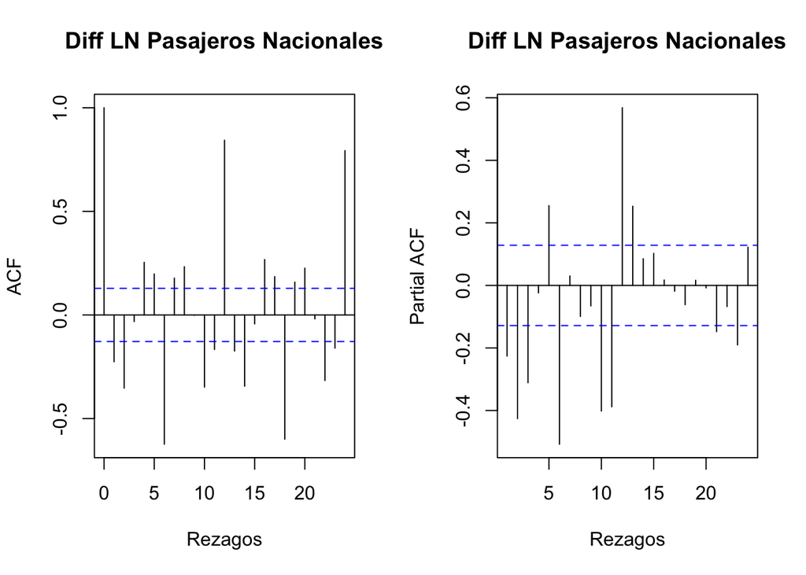

```r
par(mfrow=c(1,2))

acf(DLPax_Nal[2:234], lag.max = 24,
    xlab = "Rezagos",
    main = "Diff LN Pasajeros Nacionales")

pacf(DLPax_Nal[2:234], lag.max = 24,
     xlab = 'Rezagos',
     main = "Diff LN Pasajeros Nacionales")
```

```r
par(mfrow=c(1,1))
```

# Funciones que determinan el rezago optimo (que minimiza el criterio de Akaike)

Esta es una prueba mas formar respecto de la meta inspeccion grafica

```r
source("Lag_Opt_ARIMA_Exog.R")

# La funcion necesita de parametros definidos como:
  # Lag_Opt_ARIMA_Ex(p_max, d_max, q_max, X_t, Ex, Z_t){
  # p_max: Rezagos maximos a evaluar del componente AR
  # q_max: Rezagos maximos a evaluar del componente MA
  # d_max: Numero de diferencias evualadas
  # X_t: Serie de Tiempo modelada
  # Z_t: Vector o Matriz de variables exogenas
  # Ex: es indicador de que incluye variables exogenas (0 indica que no se incluyen, y 1 que si)
```

# Estimacion del proceso ARIMA(p, 1, q):

CON variables exogenas:

```r
Lag_Opt_ARIMA_Exog(p_max = 6, q_max = 6,
                   X_t = DLPax_Nal,
                   Ex = 1,
                   Z_t = cbind(D_Ene, D_Feb, D_Jul, D_Dic) )
```

```
##       Rezago p Rezago q       AIC Optimo
##  [1,]        1        1 -213.6716      0
##  [2,]        1        2 -242.5656      0
##  [3,]        1        3 -241.0097      0
##  [4,]        1        4 -237.5692      0
##  [5,]        1        5 -235.5706      0
##  [6,]        1        6 -250.0347      0
##  [7,]        2        1 -237.3780      0
##  [8,]        2        2 -241.8697      0
##  [9,]        2        3 -242.3131      0
## [10,]        2        4 -241.2303      0
## [11,]        2        5 -243.5664      0
## [12,]        2        6 -248.0340      0
## [13,]        3        1 -240.1965      0
## [14,]        3        2 -242.5093      0
```

[output cut: 22 more lines]

SIN variables exogenas:

```r
Lag_Opt_ARIMA_Exog(p_max = 6, q_max = 6,
                   X_t = DLPax_Nal,
                   Ex = 0,
                   Z_t = cbind(D_Ene, D_Feb, D_Jul, D_Dic))
```

```
##       Rezago p Rezago q       AIC Optimo
##  [1,]        1        1 -172.0532      0
##  [2,]        1        2 -203.6066      0
##  [3,]        1        3 -202.9020      0
##  [4,]        1        4 -202.1821      0
##  [5,]        1        5 -200.7988      0
##  [6,]        1        6 -213.6296      0
##  [7,]        2        1 -198.8304      0
##  [8,]        2        2 -204.7910      0
##  [9,]        2        3 -203.7323      0
## [10,]        2        4 -201.7334      0
## [11,]        2        5 -206.4572      0
## [12,]        2        6 -211.6908      0
## [13,]        3        1 -203.5714      0
## [14,]        3        2 -203.5399      0
```

[output cut: 22 more lines]

Estimacion:

```r
ARMA_Ex_DLPax_Nal <- arima(DLPax_Nal, order = c(3, 0, 4),
                           xreg = cbind(D_Ene, D_Feb, D_Jul, D_Dic),
                           method = "ML")
ARMA_Ex_DLPax_Nal
```

```
##
## Call:
## arima(x = DLPax_Nal, order = c(3, 0, 4), xreg = cbind(D_Ene, D_Feb, D_Jul, D_Dic),
##     method = "ML")
##
## Coefficients:
##           ar1     ar2     ar3     ma1      ma2      ma3      ma4  intercept
##       -1.0412  0.1982  0.6909  1.2918  -0.3084  -1.4115  -0.5717    -0.0132
## s.e.   0.0493  0.0854  0.0494  0.0554   0.0495   0.0462   0.0566     0.0097
##         D_Ene    D_Feb   D_Jul   D_Dic
##       -0.1346  -0.0091  0.2885  0.0605
## s.e.   0.0400   0.0424  0.0512  0.0421
##
## sigma^2 estimated as 0.01694:  log likelihood = 160.45,  aic = -294.89
```

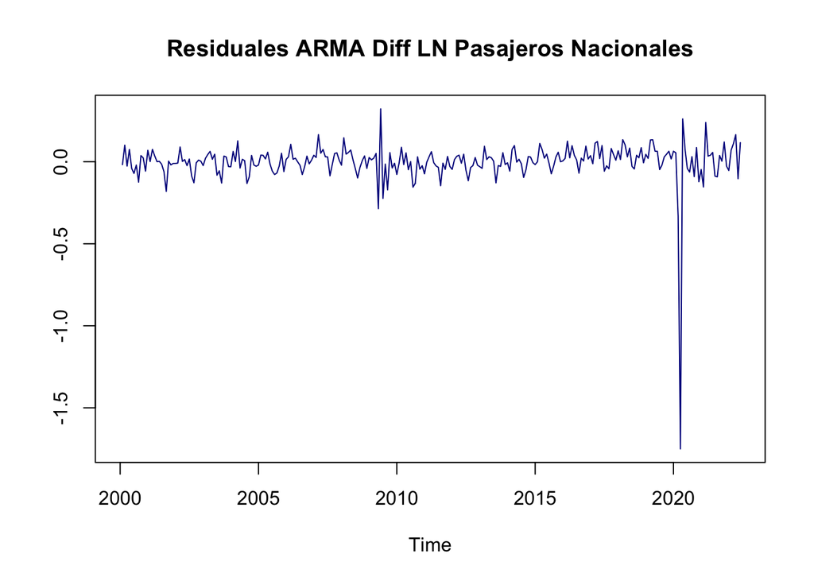

```r
plot(ARMA_Ex_DLPax_Nal$residuals,
     ylab = "",
     main = "Residuales ARMA Diff LN Pasajeros Nacionales",
     col = "darkblue")
```

# Nueva Estimacion del proceso ARIMA(p, 1, q):

CON variables exogenas rezagos optimos:

```r
Lag_Opt_ARIMA_Exog(p_max = 6, q_max = 6,
                   X_t = DLPax_Nal,
                   Ex = 1,
                   Z_t = cbind(D_Ene, D_Feb, D_Jul, D_Dic, D_Mar2020, D_Abr2020, D_Jun2020, D_Jul2020, D_Mar2021))
```

```
##       Rezago p Rezago q       AIC Optimo
##  [1,]        1        1 -535.8678      0
##  [2,]        1        2 -535.9648      0
##  [3,]        1        3 -546.3264      0
##  [4,]        1        4 -565.4627      0
##  [5,]        1        5 -571.4528      0
##  [6,]        1        6 -581.4001      0
##  [7,]        2        1 -536.3790      0
##  [8,]        2        2 -543.7421      0
##  [9,]        2        3 -594.8421      0
## [10,]        2        4 -584.7638      0
## [11,]        2        5 -582.8908      0
## [12,]        2        6 -586.1809      0
## [13,]        3        1 -514.2042      0
## [14,]        3        2 -541.7628      0
```

[output cut: 22 more lines]

```r
# Estimacion:

ARMA_Ex_DLPax_Nal_2 <- arima(DLPax_Nal, order = c(6, 0, 6),
                             xreg = cbind(D_Ene, D_Feb, D_Jul, D_Dic, D_Mar2020, D_Abr2020, D_Jun2020, D_Jul2020, D_Mar2021),
                             method = "ML")
ARMA_Ex_DLPax_Nal_2
```

```
##
## Call:
## arima(x = DLPax_Nal, order = c(6, 0, 6), xreg = cbind(D_Ene, D_Feb, D_Jul, D_Dic,
##     D_Mar2020, D_Abr2020, D_Jun2020, D_Jul2020, D_Mar2021), method = "ML")
##
## Coefficients:
##          ar1      ar2      ar3      ar4     ar5      ar6      ma1      ma2
##       0.0033  -0.0024  -0.0004  -0.0012  0.0064  -0.9970  -0.0553  -0.0687
## s.e.  0.0050   0.0041   0.0071   0.0040  0.0044   0.0029   0.0358   0.0323
##           ma3      ma4      ma5     ma6  intercept    D_Ene    D_Feb   D_Jul
##       -0.0869  -0.0183  -0.0538  0.9747     0.0195  -0.1676  -0.1675  0.1889
## s.e.   0.0313   0.0342   0.0348  0.0391     0.0041   0.0919   0.0174  0.0910
##         D_Dic  D_Mar2020  D_Abr2020  D_Jun2020  D_Jul2020  D_Mar2021
##       -0.0001    -0.4713    -1.9651     0.9067     0.5019     0.1764
## s.e.   0.0178     0.0489     0.0496     0.0542     0.0528     0.0500
##
## sigma^2 estimated as 0.002454:  log likelihood = 414.67,  aic = -783.34
```

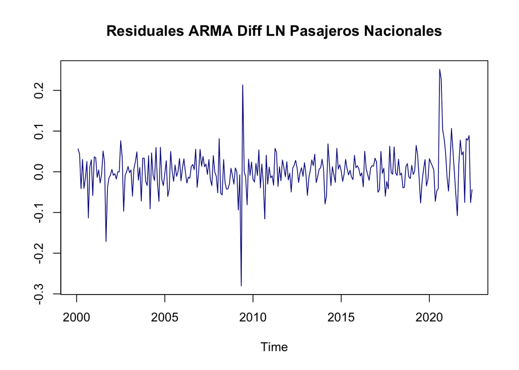

```r
plot(ARMA_Ex_DLPax_Nal_2$residuals,
     ylab = "",
     main = "Residuales ARMA Diff LN Pasajeros Nacionales",
     col = "darkblue")
```

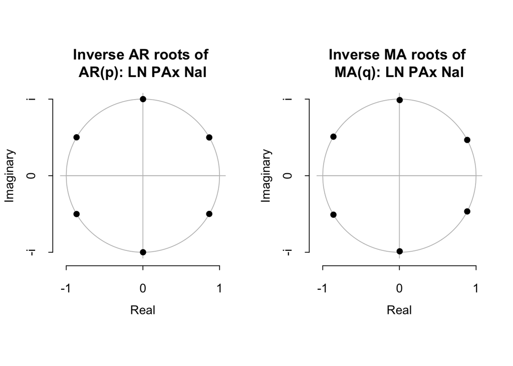

```r
#

par(mfrow=c(1,2))

plot.armaroots(arroots(ARMA_Ex_DLPax_Nal_2),
               main="Inverse AR roots of \nAR(p): LN PAx Nal")

plot.armaroots(maroots(ARMA_Ex_DLPax_Nal_2),
               main="Inverse MA roots of \nMA(q): LN PAx Nal")
```

```r
par(mfrow=c(1,1))
```